# StroopReport

Ranma Yoshida（2412C22）

## 1. 目的 (Introduction)

本研究では、ストループ効果について検討する。ストループ効果とは、文字の意味とその文字が描かれている色が不一致である場合に、文字の色を命名する反応時間が遅延する現象である。((Stroop 1935)) 本実験の仮説は「不一致条件は一致条件よりも反応時間が長くなる」とした。

## 2. 方法 (Method)

### 装置と材料

オンライン実験プラットフォームであるjsPsychを用いてストループ課題を作成した。刺激には「赤」「青」「緑」の3種類の文字を使用し、一致条件と不一致条件を設定した。

### 手続き

参加者には、画面に提示された文字の意味ではなく文字の色を判断し、赤は「r」、青は「b」、緑は「g」のキーを押して回答するよう求めた。各試行では注視点を500ms提示した後に刺激を呈示し、回答後は1000msの試行間隔を設けた。実験は全10試行で実施し、反応時間と正答率を記録した。

## 3. 結果 (Results)

```
# A tibble: 2 × 5
  condition   mean_rt sd_rt     n se_rt
  <chr>         <dbl> <dbl> <int> <dbl>
1 congruent       480  30       3  17.3
2 incongruent     605  21.2     2  15
```

[output not shown]

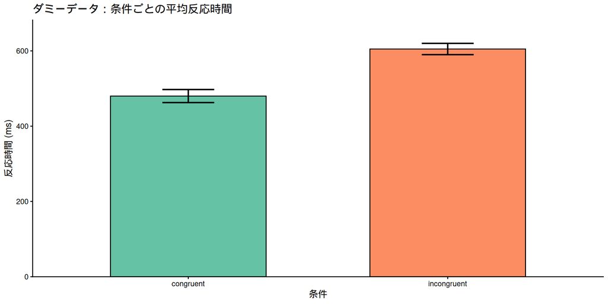

## 5. 引用文献 (References)

Stroop, J. R. 1935. “Studies of Interference in Serial Verbal Reactions.” *Journal of Experimental Psychology* 18 (6): 643–62. https://doi.org/10.1037/h0054651.